# 31446_A6

## A6

**Data Visualization III**

Download the Iris flower dataset or any other dataset into a DataFrame.

(e.g., https://archive.ics.uci.edu/ml/datasets/Iris ).

Scan the dataset and give the inference as:

1. List down the features and their types (e.g., numeric, nominal) available in the dataset.
2. Create a histogram for each feature in the dataset to illustrate the feature distributions.
3. Create a boxplot for each feature in the dataset.
4. Compare distributions and identify outliers.

**Link of Dataset**

Iris: https://www.kaggle.com/datasets/saurabh00007/iriscsv

**1) Import Required Libraries**

pandas → data handling

numpy → numerical operations

matplotlib & seaborn → graphs/plots

```python
import numpy as np
import pandas as pd
import matplotlib.pyplot as plt
import seaborn as sns
```

**2) Load the Dataset**

```python
# Load the Iris dataset
df = pd.read_csv("Iris.csv")
```

```python
# Display first 5 rows
df.head()
```

|  | Id | SepalLengthCm | SepalWidthCm | PetalLengthCm | PetalWidthCm | Species |
| --- | --- | --- | --- | --- | --- | --- |
| 0 | 1 | 5.1 | 3.5 | 1.4 | 0.2 | Iris-setosa |
| 1 | 2 | 4.9 | 3.0 | 1.4 | 0.2 | Iris-setosa |
| 2 | 3 | 4.7 | 3.2 | 1.3 | 0.2 | Iris-setosa |
| 3 | 4 | 4.6 | 3.1 | 1.5 | 0.2 | Iris-setosa |
| 4 | 5 | 5.0 | 3.6 | 1.4 | 0.2 | Iris-setosa |

**3) Understand Dataset Structure**

```python
# Dimmensions of dataset
df.shape
```

```
(150, 6)
```

```python
# Datatypes of each column
df.dtypes
```

```
Id                 int64
SepalLengthCm    float64
SepalWidthCm     float64
PetalLengthCm    float64
PetalWidthCm     float64
Species           object
dtype: object
```

### 1. List down the features and their types (e.g., numeric, nominal) available in the dataset.

**Features and Their Data Types**

| Feature Name | Data Type | Description |
| --- | --- | --- |
| sepal_length | Numeric | Sepal length in cm |
| sepal_width | Numeric | Sepal width in cm |
| petal_length | Numeric | Petal length in cm |
| petal_width | Numeric | Petal width in cm |
| species | Nominal | Type of iris flower |

**Inference:**

- The dataset contains **4 numeric features** and **1 categorical feature**.
- Numeric features are suitable for statistical visualization.

```python
# Display info of dataset
df.info()
```

```
<class 'pandas.core.frame.DataFrame'>
RangeIndex: 150 entries, 0 to 149
Data columns (total 6 columns):
 #   Column         Non-Null Count  Dtype
---  ------         --------------  -----
 0   Id             150 non-null    int64
 1   SepalLengthCm  150 non-null    float64
 2   SepalWidthCm   150 non-null    float64
 3   PetalLengthCm  150 non-null    float64
 4   PetalWidthCm   150 non-null    float64
 5   Species        150 non-null    object
dtypes: float64(4), int64(1), object(1)
memory usage: 7.2+ KB
```

```python
# Display statistical summary
df.describe()
```

|  | Id | SepalLengthCm | SepalWidthCm | PetalLengthCm | PetalWidthCm |
| --- | --- | --- | --- | --- | --- |
| count | 150.000000 | 150.000000 | 150.000000 | 150.000000 | 150.000000 |
| mean | 75.500000 | 5.843333 | 3.054000 | 3.758667 | 1.198667 |
| std | 43.445368 | 0.828066 | 0.433594 | 1.764420 | 0.763161 |
| min | 1.000000 | 4.300000 | 2.000000 | 1.000000 | 0.100000 |
| 25% | 38.250000 | 5.100000 | 2.800000 | 1.600000 | 0.300000 |
| 50% | 75.500000 | 5.800000 | 3.000000 | 4.350000 | 1.300000 |
| 75% | 112.750000 | 6.400000 | 3.300000 | 5.100000 | 1.800000 |
| max | 150.000000 | 7.900000 | 4.400000 | 6.900000 | 2.500000 |

**4) Handle missing values**

```python
# Check missing values
df.isnull().sum()
```

```
Id               0
SepalLengthCm    0
SepalWidthCm     0
PetalLengthCm    0
PetalWidthCm     0
Species          0
dtype: int64
```

### 2. Create a histogram for each feature in the dataset to illustrate the feature distributions.

**a) Histogram of feature: Sepal Length**

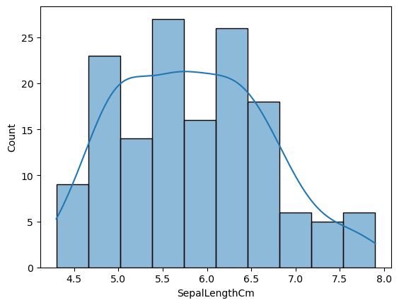

```python
sns.histplot(data=df, x="SepalLengthCm", bins=10, kde=True)
```

**Inference:**

- The distribution is slightly right-skewed.
- Most values lie between 5.0 cm and 6.5 cm.
- No extreme outliers are visible.

**b) Histogram of feature: Sepal Width**

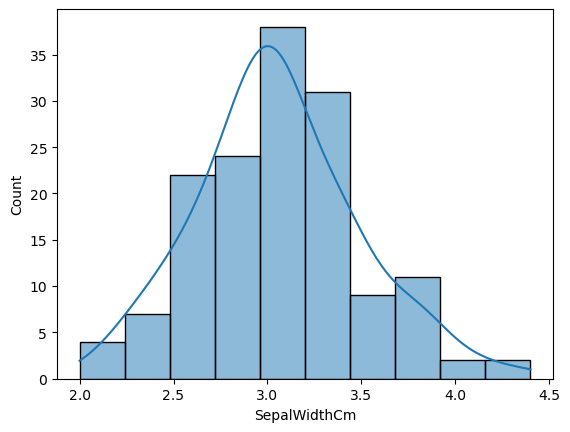

```python
sns.histplot(data=df, x="SepalWidthCm", bins=10, kde=True)
```

**Inference:**

1. The distribution is moderately symmetric.
2. Most values are between 2.5 cm and 3.5 cm.
3. A few values fall outside the main range, indicating possible outliers.

**c) Histogram of feature: Petal Length**

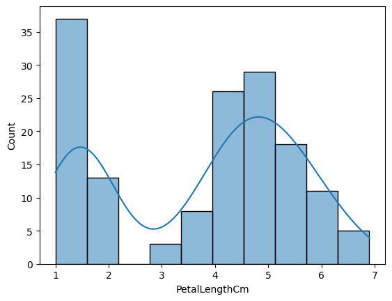

```python
sns.histplot(data=df, x="PetalLengthCm", bins=10, kde=True)
```

**Inference:**

- The distribution is bimodal, showing two distinct peaks.
- This indicates clear separation among flower species.
- Values mostly range from 1.0 cm to 6.5 cm.

**d) Histogram of feature: Petal Width**

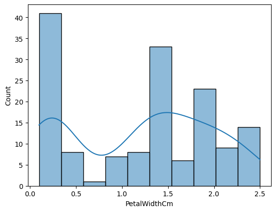

```python
sns.histplot(data=df, x="PetalWidthCm", bins=10, kde=True)
```

**Inference:**

- The distribution is also bimodal.
- Most values lie between 0.1 cm and 2.5 cm.
- This feature is highly useful for classification.

### 3. Create a boxplot for each feature in the dataset.

**a) Boxplot of All Numerical Features**

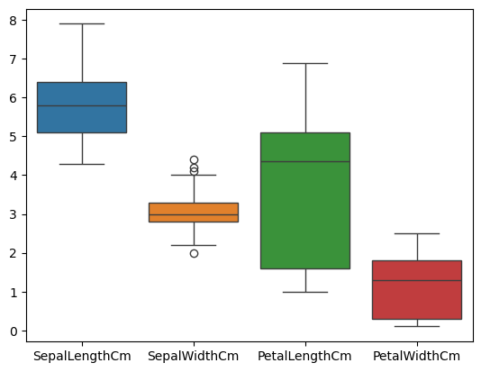

```python
sns.boxplot(data=df.drop(["Id", "Species"], axis=1))
```

**Inference:**

- Sepal width shows outliers
- Petal features have wider spread and better separation.

**b) Boxplot of Sepal Length by Species**

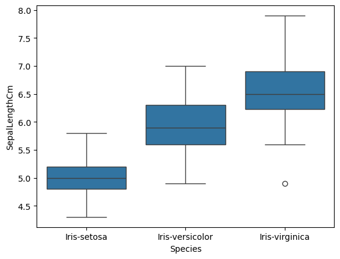

```python
sns.boxplot(data=df, x="Species", y="SepalLengthCm")
```

**Inference:**

- Virginica has the highest sepal length
- Versicolor in between
- Setosa has the lowest.

**c) Boxplot of Sepal Width by Species**

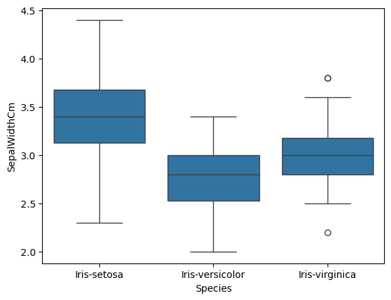

```python
sns.boxplot(data=df, x="Species", y="SepalWidthCm")
```

**Inference:**

- Setosa has the highest median sepal width.
- Versicolor and Virginica have similar, lower medians.
- A few outliers are present in virginica.

**d) Boxplot of Petal Length by Species**

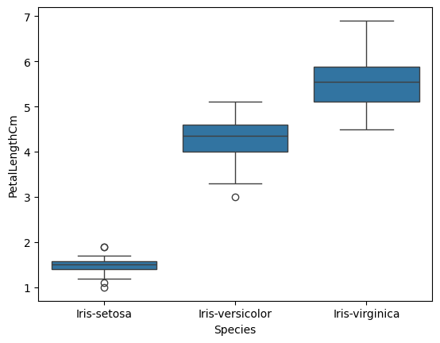

```python
sns.boxplot(data=df, x="Species", y="PetalLengthCm")
```

**Inference:**

- Setosa has the smallest petal length with some outliers.
- Virginica has the largest petal length.
- Clear separation among all three species.

**e) Boxplot of Petal Width by Species**

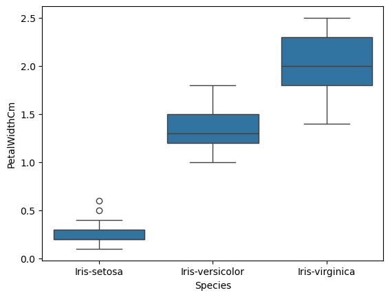

```python
sns.boxplot(data=df, x="Species", y="PetalWidthCm")
```

**Inference:**

- Setosa has the smallest petal width with some outliers.
- Virginica has the largest petal width.
- Clear separation among species.

### 4. Compare Distributions and Identify Outliers

**Inference:**

- Sepal width shows outliers.
- Sepal length has moderate spread with no major outliers.
- Petal length and width are well-distributed with very few outliers.
- Petal features are more useful for classification.

**Final Summary/Conclusion:**

- The dataset has 4 numeric and 1 categorical feature.
- Outliers are mainly in sepal width.
- Petal features are more consistent and discriminative.